# Assignment007: Data wrangling 2

Mislav

2021/11/12 11:11:47

> 作業演練項目說明，請見[電子書](https://rstat-project.github.io/ug1-practical/data-wrangling-2.html)及[中文講義](https://rstat-project.github.io/ug-tactic/%E9%80%B1-06_%E8%B3%87%E6%96%99%E6%B8%85%E7%90%86%E6%8A%80%E5%B7%A7%E4%B8%8B.html)。

## 練習1 Set up and loading data

```r
knitr::opts_chunk$set(echo = TRUE)
## 使用Assingment004的setup chunk載入正向心理學資料`dat`,`pinfo`及tidyverse套件
setwd('C:/Users/USER/Desktop/STATS/level01-assignment006-krizic2')
dat <- read_csv('ahi-cesd.csv',show_col_types = F)
pinfo <- read_csv("participant-info.csv", show_col_types = F)
```

- 所有練習項目除了放置達成練習目標的程式碼及執行成果，也要說明測試程式碼的發現，以及你對執行成果的解讀。
- 本單元除了電子書的演練問題，也要嘗試演練及解答加碼挑戰題。
- 每項演練問題採用`inline code`彙整，有助之後參考使用。

## 練習2

依照電子書演練1及2的指示，製造`all_dat`與`summarydata`。

```r
all_dat <- inner_join(dat,pinfo,by=c('id','intervention'))
summarydata <- select(all_dat,ahiTotal, cesdTotal, sex, age, educ, income, occasion, elapsed.days)
```

問題：電子書指示在此移除“intervention”變項，你認為這一步會對這個單元的演練任務有什麼影響？

## 練習3

```r
ahi_asc <- arrange(summarydata, by = desc(cesdTotal))
# alternative 1
ahi_asc[1,2]
```

```
## # A tibble: 1 x 1
##   cesdTotal
##       <dbl>
## 1        55
```

```r
ahi_asc[nrow(ahi_asc),2]
```

```
## # A tibble: 1 x 1
##   cesdTotal
##       <dbl>
## 1         0
```

```r
# alternative 2
min(summarydata$cesdTotal)
```

```
## [1] 0
```

```r
max(summarydata$cesdTotal)
```

```
## [1] 55
```

```r
age_young <- filter(ahi_asc, age >=18, age <=45)
```

挑戰：篩選18歲到45歲的參與者，存入資料物件`age_young`。

## 練習5

```r
data_summary <- summarise(age_young, mean=mean(cesdTotal), median=median(cesdTotal))
data_summary
```

```
## # A tibble: 1 x 2
##    mean median
##   <dbl>  <dbl>
## 1  13.6     11
```

挑戰：計算`age_young`的“cesdTotal”的平均值及中位數。

## 練習6

```r
cesd_data <- group_by(age_young,occasion)
data_summary2 <- summarise(cesd_data, mean=mean(cesdTotal), median=median(cesdTotal))
data_summary2
```

```
## # A tibble: 6 x 3
##   occasion  mean median
##      <dbl> <dbl>  <dbl>
## 1        0  16.1   14
## 2        1  12.3    9.5
## 3        2  13.2   10
## 4        3  12.5    9.5
## 5        4  11.5    8.5
## 6        5  12.5    9.5
```

挑戰：製作依受測時間點“occasion”分組的`age_young`資料，使用`head()`預覽資料。

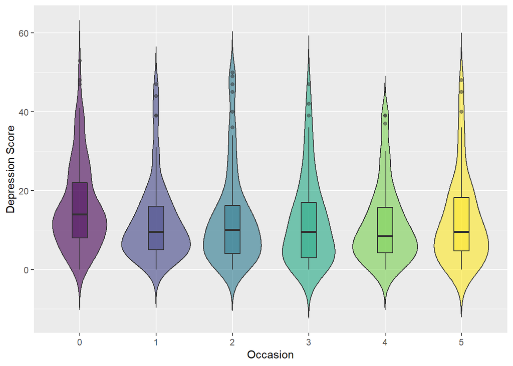

```r
## 課後演練區
ggplot(cesd_data, aes(x = as.factor(occasion), y = cesdTotal, fill = as.factor(occasion))) +
  geom_violin(trim = FALSE, show.legend = FALSE, alpha = .6) +
  geom_boxplot(width = .2, show.legend = FALSE, alpha = .5) +
  scale_fill_viridis_d(option = "D") +
  scale_x_discrete(name = "Occasion", labels = c("0", "1", "2","3","4","5")) +
  scale_y_continuous(name = "Depression Score")
```

## 練習7

挑戰：使用分組的`age_young`資料，繪製violine plot合併boxplot，根據“occasion”回答有關不同教育程度及憂鬱分數的問題。

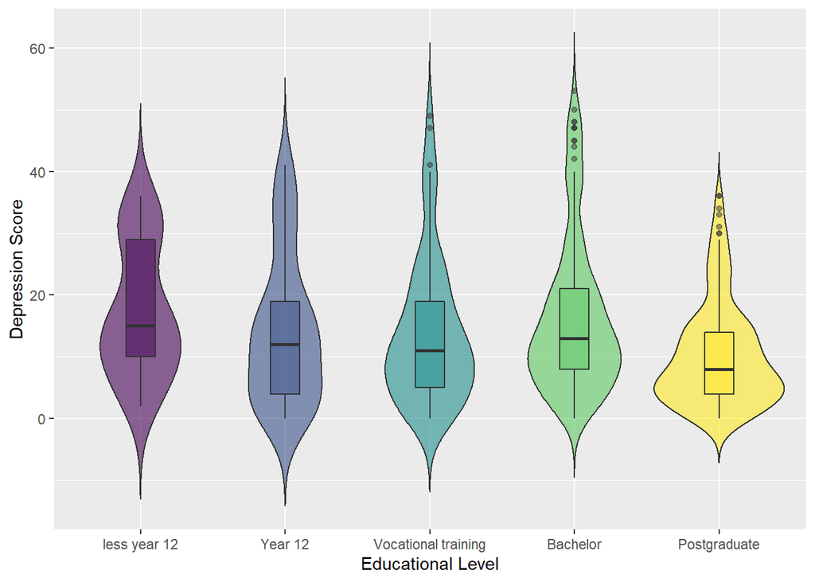

```r
educ_data <- group_by(age_young,educ)
## 課後演練區
ggplot(educ_data, aes(x = as.factor(educ), y = cesdTotal, fill = as.factor(educ))) +
  geom_violin(trim = FALSE, show.legend = FALSE, alpha = .6) +
  geom_boxplot(width = .2, show.legend = FALSE, alpha = .5) +
  scale_fill_viridis_d(option = "D") +
  scale_x_discrete(name = "Educational Level", labels = c("less year 12", "Year 12", "Vocational training","Bachelor","Postgraduate")) +
  scale_y_continuous(name = "Depression Score")
```

## 練習8

請見原始論文的Table 2。

> 為了減輕教練與助教批改工作負擔，活用成果請回覆在討論區單元帖。 **活用**：分享你重製Table 2的成果，預期程式碼很長，推薦使用[gist](https://gist.github.com/)整理程式碼和執行結果，方便在討論區交流。繳交期限之後在討論區點評，還原度越高者，emoji點數越多。